# Practical Machine Learning Project

Peter Saunders

Sunday, January 18, 2015

## Project Aims

The aim of this project is to produce a machine learning algorithm to predict the quality with which a bicep curl was performed from data obtained from sensors on the dumbbell and the athlete’s belt, arm and forearm.

## Data Exploration and Cleaning

I began by loading the Weight Lifting Exercise training dataset into R to explore its structure. I used the functions `str` and `summary` to look at the structure of the data.

```r
#Load packages
require(caret)
require(randomForest)

#Load training data
trainingDf = read.csv("./data/pml-training.csv")
```

The raw data-frame contains 19622 rows and 160 columns but, looking at the summary information, I was able to identify 100 columns which contained mostly missing (either NA or empty string) data.

```r
#Find columns with NAs or empty strings
naCount      = apply(trainingDf, 2, function(x)length(which(is.na(x))))
missingCount = apply(trainingDf, 2, function(x)length(which(x == "")))
summaryColumns = sort(names(which(naCount > 0 | missingCount > 0)))
```

These column names all had the prefixes:

- amplitude
- avg
- kurtosis
- max
- min
- skewness
- stddev
- var

These columns only contain numeric values in the rows where `new_window = yes` and the names suggest that these are summary statistics for each window. Since we are aiming to predict the class from a single row I decided to discard these columns and those referring to the windows, `new_window` and `num_window`.

```r
#Select the non-summary columns
windowColumns  = which(names(trainingDf) %in% c("new_window", "num_window"))
summaryColumns = which(naCount > 0 | missingCount > 0)
trainingDf = trainingDf[, -c(windowColumns, summaryColumns)]
```

The data-frame now contains 58 columns and has no missing values. The columns are:

- 1 index column, `X`
- 1 user column, `user_name`
- 3 timestamp columns
- 52 data columns from the sensors on the belt, arm, dumbbell and forearm
- 1 outcome column, `classe`

I decided to also remove the index, user and timestamp columns. Because the data is ordered by the ‘classe’ (A-E) variable it will be highly correlated with X and the timestamp variables, although these are not meaningful as predictors outside of this particular training set and would give a highly biased estimate for the out-of-sample error.

```r
#Remove index, user and timestamp columns
trainingDf = trainingDf[, 6:58]
```

## Model Building and Cross-Validation

I decided to use k-fold cross-validation and a random-forest method to build a prediction algorithm.

I started by splitting the data into the training/testing set and a validation set. I used ~80% of the data for training/testing and the remaining 20% for validation.

```r
#Separate data into training and validation sets
#and remove index, user and timestamp columns
set.seed(3485)
modelIdx = createDataPartition(trainingDf$classe, p = 0.8, list = FALSE)

modelData       = trainingDf[modelIdx, ]
validationData  = trainingDf[-modelIdx, ]
```

I then ran K-fold cross-validation, each time building a random forest and storing that model.

I tried several different values and found that K = 15 was a good compromise between bias and variance and did not take too long to evaluate.

```r
#Now do k-fold cross-validation
K = 15
kfolds = createFolds(modelData$classe, k = K, list = TRUE, returnTrain = TRUE)
models = vector(length = K, mode = "list")

for (i in 1:K) {
    kthTraining = modelData[kfolds[[i]], ]  #make training
    kthTesting  = modelData[-kfolds[[i]], ] #make testing

    #Make model and store it
    kthRF = randomForest(classe ~., data=kthTraining, ntree=500, norm.votes=FALSE)
    models[[i]] = kthRF

    #Evaluate on testing set to print accuracy
    kthPreds = predict(kthRF, newdata = kthTesting)

    cm = confusionMatrix(kthPreds, kthTesting$classe)
    cat("Accuracy[", i, "] = ", cm$overall['Accuracy'], "\n", sep="")
}
```

```
## Accuracy[1] = 0.9961796
## Accuracy[2] = 0.9961722
## Accuracy[3] = 0.995229
## Accuracy[4] = 0.9971319
## Accuracy[5] = 0.995229
## Accuracy[6] = 0.9942584
## Accuracy[7] = 0.9952199
## Accuracy[8] = 0.9952245
## Accuracy[9] = 0.9961759
## Accuracy[10] = 0.9952245
## Accuracy[11] = 0.9952245
## Accuracy[12] = 0.9942748
## Accuracy[13] = 0.9942639
## Accuracy[14] = 0.9971319
## Accuracy[15] = 0.9961796
```

To estimate the out-of-sample error I ran each of the models on the validation data-set.

```r
#Use all of the models to make predictions
validationPreds = lapply(models, function(x){predict(x, newdata = validationData)})
validationMatrix = matrix(unlist(validationPreds), ncol = nrow(validationData), nrow = K, byrow = TRUE)
```

I then used a ‘vote’ of the model results to select the most common (modal) prediction from the K models.

```r
#Use vote of each of the K models to form prediction
vote <- function(x) {
    ux = unique(x)
    ux[which.max(tabulate(match(x, ux)))]
}

finalPredict = apply(validationMatrix, MARGIN = 2, vote)
```

I then looked at the measures of accuracy and the confusion matrix to estimate the out-of-sample error.

```r
#Examine confusion matrix and statistics
finalCm = confusionMatrix(finalPredict, validationData$classe)

cat("Final validation accuracy =", finalCm$overall['Accuracy'], "\n")
```

```
## Final validation accuracy = 0.9966862
```

```r
print(finalCm$table)
```

```
##           Reference
## Prediction    A    B    C    D    E
##          A 1115    2    0    0    0
##          B    1  757    4    0    0
##          C    0    0  680    3    1
##          D    0    0    0  639    1
##          E    0    0    0    1  719
```

I decided to look at the most important variables and plot them to see how separable the classes are within these variables.

```r
### Look at the most important variables in the models ###
require(AppliedPredictiveModeling)
require(ellipse)

topNImportant <- function(model, N=4) {
    imps     = importance(model)
    rankedVars = rownames(imps)[order(imps, decreasing=TRUE)]
    topN = rankedVars[1:N]

    return(topN)
}

importantVars = sapply(models, topNImportant)
top4Overall   = apply(importantVars, 1, vote)
cat("Most important variables: ", paste(top4Overall, collapse=", "), "...", sep="")
```

```
## Most important variables: roll_belt, yaw_belt, pitch_forearm, magnet_dumbbell_z...
```

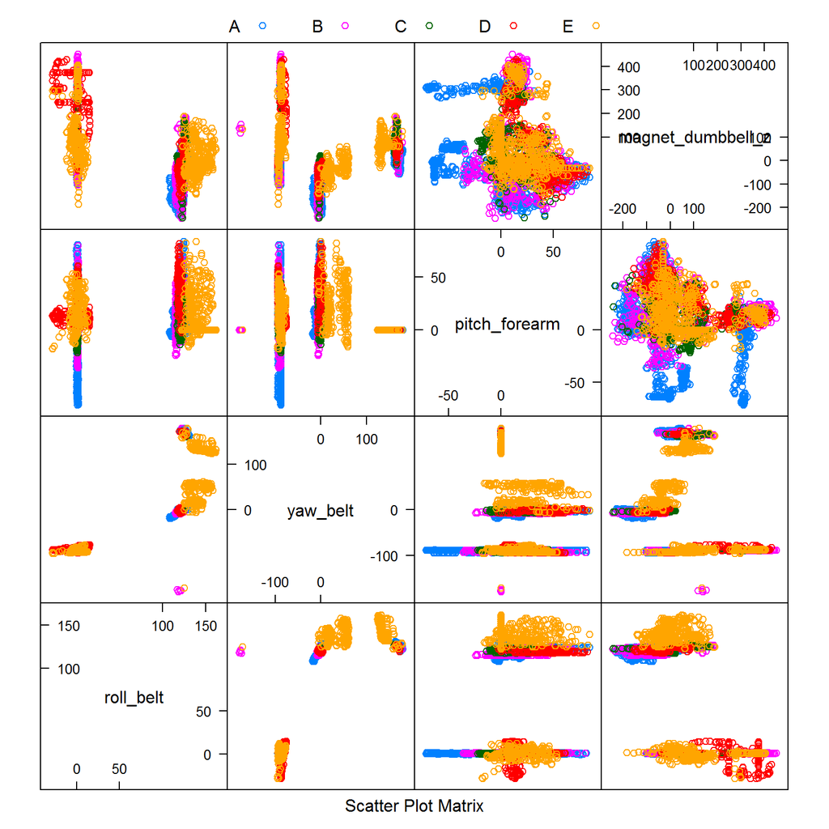

```r
featurePlot(x = validationData[, top4Overall],
            y = validationData$classe,
            plot = "pairs",
            #visual args
            auto.key = list(columns = 5))
```

## Conclusions

Using a random forest approach I was able to produce a highly accurate algorithm for predicting the ‘classe’ of the exercise performed.

Plotting the most important variables shows that there is very little differentiation between the classes in any single variable. The model is accurate because it uses a large number (52) of predictors and the aggregated random forest approach is well-suited to problems such as these.